# Univariate Stats Week 1

September 21, 2016

## Welcome to R Lab!

TA: Arlie Belliveau, MA

History & Theory of Psychology

arliebelliveau@gmail.com

Office: BSB 059 by appointment **(email me first)**

## This Week's Plan: The Basics

- What is R? Why R?
- Install R
- The Console
- Getting Started
- Install non-base libraries

## What is R?

R is an open source language and environment for statistical computing and graphics.

It is based on S, which was a language developed by Bell Laboratories in the 1970s.

There is an R Development Core Team who write the R source code, the R Foundation who control the design and evolution of base R, and the R Project, which features thousands of international contributors. UseRs develop their own collection of funcitons called "packages", which can be publicly distributed on the Comprehensive R Archive Network (CRAN). That's where we will get many of our functions!

## Why R?

It's **free** and will always be free and open source.

Community:

- **Ask questions**: http://stackexchange.com
  - R questions: http://stackoverflow.com/
  - General statistics: http://stats.stackexchange.com/
- R Bloggers: r-bloggers.com
- DataCamp: datacamp.com
- Examples and tips: statmethods.net
- Search R specific sites: rseek.org
- Cheat sheets: onepager.togaware.com

## Why R?…

Designed for statistical operations, so almost all statistical methods are available, especially the very new ones!

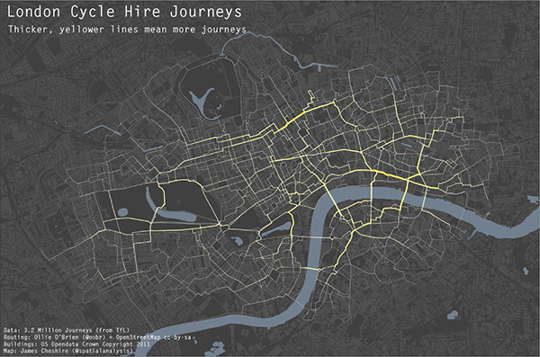

Beautiful graphics, analysis, text mining, interactive visualizations, and even slide presentations (like this one)!

## Installing R

1. Go to the website: https://www.r-project.org/
2. Click Download R: https://cran.r-project.org/mirrors.html
3. Select your mirror (server): University of Toronto: http://cran.utstat.utoronto.ca/
4. Download R for appropriate platform:
- R 3.3.1 binary for Mac OS X 10.9 (Mavericks)
- Base -> R 3.3.1 for Windows
- Linux (you can figure it out if you are running linux)

## R

This is R

[figure not shown]

If you have a solid coding background, R may be enough for you. If you are more comfortable with GUI (graphic user interfaces), RStudio is a better option.

## Installing RStudio

1. Go to the website: https://www.rstudio.com/
2. Click "Download R Studio"
3. Open Source Edition (that means it's FREE!)
4. Download R Studio Desktop: https://www.rstudio.com/products/rstudio/download/
- Mine is OS X 10.6 -> note which version you have because some code and packages only work with certain versions.
- For more installation instructions you can visit: https://github.com/MHS-R/R-Guide/wiki/Installing-R

## The RStudio Console

[figure not shown]

## Getting Started

To write a new R script, go to **File** and select **New File** then **R Script**.

If you already have a file saved that you want to open, click **File** then **Open File**.

[figure not shown]

.R files are text files, so you can edit them in any text editor across platforms.

## Base R

RStudio comes with a "base" library that has many functions, like addition and division, that will return output:

```r
4+4
```

```
## [1] 8
```

## Install Non-Base Libraries

For `functions` that are not in the base program, we need to install `packages`. Go to the "Packages" tab and click "Install". Choose "Repository (CRAN)" from the drop-down menu, then type the name of the package you want into the search bar and click "Install". **Install all dependencies.**

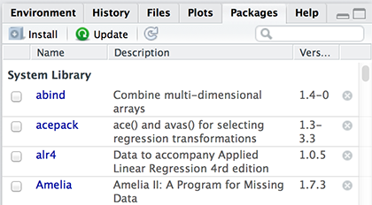

You will be able to scroll through your packages to see which ones are selected at any given time.

## Non-CRAN Packages

We can install `beta packages` not on CRAN by downloading them from the web (https://github.com/trending?l=R), select "Install from Package Archive File".

[figure not shown]

- There will be less support in the communities for beta packages, but often the developers will answer your questions if you email them directly.